# Global Cropland Expansion and Soils at Risk

A Terra Tutorial

Mandy Liesch

# Purpose

*Scientific Purpose:* There are several causes of [anthropogenic climate changes](https://www.ipcc.ch/site/assets/uploads/2019/08/4.-SPM_Approved_Microsite_FINAL.pdf). Land use change, especially deforestation and cropland expansion, creates several different emissions that contribute to extra carbon dioxide in the atmosphere. The scientific objective of this vignette is to visualize the cropland gains by country, as well as the soil carbon levels of these countries. The second portion of the Vignette focuses only on the pixels that are experiencing greater than 10% conversion into croplands, and their soil carbon content. This second objective identifies which areas are experiencing high levels of conversion, with high carbon. These ares are considered high risk areas.

*Coding Purpose:* The purpose of this vignette is exploring the functionality of the `Terra` package for manipulating rasters, masking, and clipping. Terra is an evolution to the raster package, and stores information, especially large raster files, into a computer in a way that makes them faster and easier to process. Once these initial processing steps are done, the `exact_extract` and `raster` package to extract the zonal statistics into an attribute table. The terra package has an extract option; however, it is much slower when processing large, and more complex datasets [(though much faster with smaller ones)](https://tmieno2.github.io/R-as-GIS-for-Economists/extraction-speed-comparison.html). Then, these spatVectors will be merged with the coulumns created from the raster values, and visualized with bivariate cholopleth maps in `ggplot`.

A Note on file size:

A lot of these files, especially the temporary ones are quite large in RAM. There are several ways to deal with this, including the use of [`terraOptions`](https://rdrr.io/github/rspatial/terra/man/tmpFile.html#:~:text=Description,you%20cannot%20provide%20a%20filename.). To get around this, I used an external hard drive (F:/) to change where the temporary Spatraster files are stored using this command. This function eliminated the failures caused by a full temp drive.

`terraOptions(tempDir="F:/temp")`

# R Packages

## Spatial Processing Packages

[`terra`](https://cran.r-project.org/web/packages/terra/terra.pdf): This package is the new gold standard in geospatial processing. It is faster than the raster and sf package, and was designed specifically for satellite image processing and other large raster projects. There is an extensive [geospatial tutorial](https://rspatial.org/terra/spatial/index.html) with many examples.

[`geodata`](https://cran.r-project.org/web/packages/geodata/geodata.pdf): A package for the downloading geographic data, including administrative boundaries at several levels.

[`exactextractr`](https://cran.r-project.org/web/packages/exactextractr/exactextractr.pdf): This package allows fast extraction of raster data to shapefiles.

The Geospatial Data Abstraction Library (GDAL), is an open source software for reading and writing raster and vector geospatial data formats. It is integrated in many different softwares, and supports many different file types. There are two different gdal packages.

[`rgdal`](https://cran.r-project.org/web/packages/rgdal/rgdal.pdf): This is the R software integration of the Geospatial Data Abstraction Library (GDAL). *Please note that ‘rgdal’ will be retired by the end of 2023, plan transition to sf/stars/‘terra’ functions using ‘GDAL’ and ‘PROJ’ at your earliest convenience.*

[`gdalUtils`](https://www.rdocumentation.org/packages/gdalUtils/versions/2.0.3.2): This is the developmental raster tool behind the Geospatial Data Abstraction Library (GDAL).

[`sf`](https://cran.r-project.org/web/packages/sf/sf.pdf): a standardized way to encode spatial vector data that binds to ‘GDAL’ for reading and writing data.

## Visualization Packages

[`ggplot2`](https://ggplot2.tidyverse.org/): A part of the R tidyverse, and one of the most versatile graphics package, with builds and extensions.

Ridge plots are a chart that is used to visualize distributions of several groups of a category, in this case, the distributions are covered by region/continent.

[`ggridges`](https://cran.r-project.org/web/packages/ggridges/vignettes/introduction.html):

A Bivariate Chloropleth Maps are a type of thematic visualization that present two or more different numeric values on a single map. The chloropleth map is the most standard of these, with each value (in this case, country), getting classified into a two dimensional matrix (with value 1 determined by one variable, and value 2 determined by the second variable). The legend is divided into smaller boxes where each box represents a unique relationship of the variables (category 1-1, up to category 3-3). To run this analysis, these packages are required:

[`biscale`](https://cran.r-project.org/web/packages/biscale/biscale.pdf): This method is used with ggplot to create the matrix necessary to make bivariate choloropleth maps.

[`cowplot`](https://www.rdocumentation.org/packages/cowplot/versions/1.1.1): This package is a generic graphics package that provides help with creating publication-quality figures with ggplot. For the bivariate chloropleth maps, it helps us add the legend and dynamic positioning. There are several other functions it can do.

## Data Manipulation Packages

There are several packages used for this analysis and visualization:

`tidyverse`

`rmarkdown`

```r
library(biscale)
library(cowplot)
library(exactextractr)
library(gdalUtils)
library(geodata)
library(ggplot2)
library(ggridges)
library(rgdal)
library(rmarkdown)
library(sf)
library(terra)
library(tidyverse)

terraOptions(tempDir="F:/temp")
```

# Raw Data and Preparations

## Countries

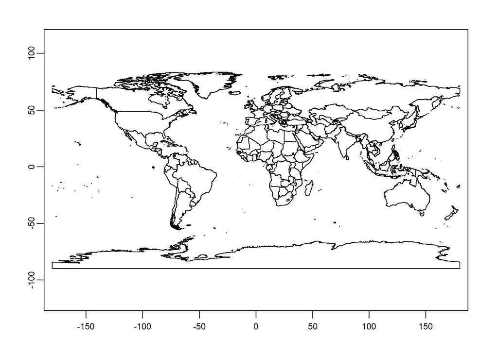

```r
w <- world(path=tempdir())

plot(w)
```

```r
w
```

```
##  class       : SpatVector
##  geometry    : polygons
##  dimensions  : 231, 2  (geometries, attributes)
##  extent      : -180, 180, -90, 83.65625  (xmin, xmax, ymin, ymax)
##  coord. ref. : +proj=longlat +datum=WGS84 +no_defs
##  names       : GID_0      NAME_0
##  type        : <chr>       <chr>
##  values      :   ABW       Aruba
##                  AFG Afghanistan
##                  AGO      Angola
```

## Soil Grids: Total Soil Carbon Stocks 0-30 cm

SoilGrids is a system for global digital soil mapping that makes use of global soil profile information and covariate data to model the spatial distribution of soil properties across the globe. SoilGrids is a collections of soil property maps for the world produced using machine learning at 250 m resolution. The [Soil Grids 2.0 FAQs](https://www.isric.org/explore/soilgrids/faq-soilgrids#How_can_I_access_SoilGrids) details the file structure and downloads for both the soil grids data for soil carbon, as well as the uncertainty.

This code process takes you through how to grab the WebDAV protocol modelled off of the [SoilGrids Notebook](https://git.wur.nl/isric/soilgrids/soilgrids.notebooks/-/blob/master/markdown/webdav_from_R.md), using the GDAL functionality in R.

```r
library(rgdal)
library(gdalUtils)

link="/vsicurl/https://files.isric.org/soilgrids/latest/data/ocs/ocs_0-30cm_Q0.5.vrt"

gdal_translate(link,
    "soilC_Rast.tif",
    co=c("TILED=YES","COMPRESS=DEFLATE","BIGTIFF=YES"),
    verbose=TRUE)
```

```r
scStock<-rast("soilC_Rast.tif")

plot(scStock)

project(scStock, w, filename="Reproj_SoilC.tif")
```

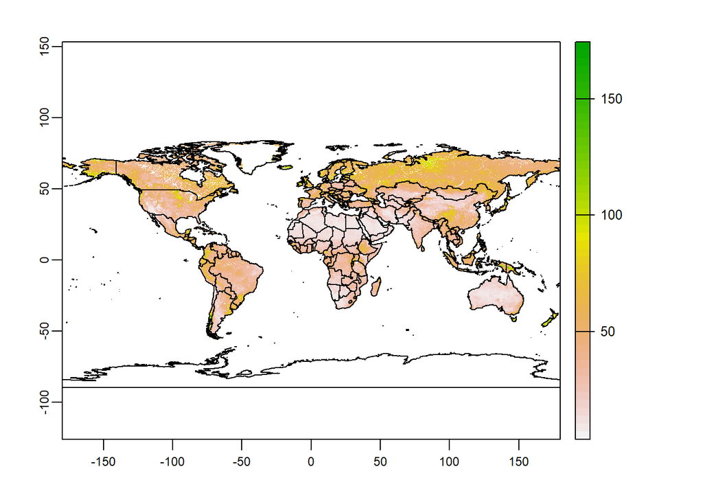

```r
scStock<-rast("Reproj_SoilC.tif")

plot(scStock)
plot(w, bg="transparent", add=TRUE)
```

## Cropland Extent Changes

The dataset represents a globally consistent cropland extent time-series at 30-m spatial resolution. Cropland defined as land used for annual and perennial herbaceous crops for human consumption, forage (including hay), and biofuel. It is on the [Global Land Analysis and Discovery](https://glad.umd.edu/dataset/croplands), on a project through the University of Maryland.

The chosen rasters downloaded are the Cropland Gain (Global_cropland_3km_netgain.tif).

The net cropland extent change from 2003 to 2019 is shown as the Pixel value: 0-100, percent of cropland dynamic (loss or gain) per pixel.

```r
cropGain<-rast("Global_cropland_3km_netgain.tif")


project(cropGain, scStock, filename="Reproj_cropGain.tif")
```

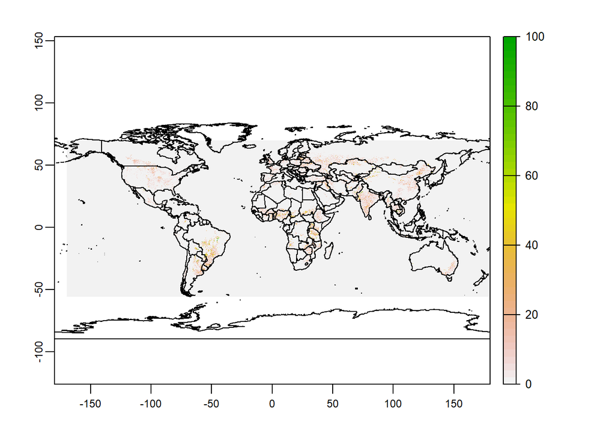

```r
gains<-rast("Reproj_cropGain.tif")

plot(gains)
plot(w, bg="transparent", add=TRUE)
```

# Preliminary Analysis

```r
shapeSF <- sf::st_as_sf(w)

regions<-read_csv("regions.csv")

shapes<-merge(shapeSF, regions, by="GID_0")

shapes$TotalCount<-exact_extract(scStock, shapes, 'count')
shapes$totC_Mean<-exact_extract(scStock, shapes, 'mean')
shapes$cropGains_Mean<-exact_extract(gains, shapes, 'mean')
```

## Tables by Region

```r
summary<-na.omit(shapes)
summary$geometry<-NULL


sumStats <- summary %>%
  group_by(Region) %>%
  summarise_at(vars(totC_Mean, cropGains_Mean), list(name = mean))
```

```r
sumStats
```

```
## # A tibble: 18 x 3
##    Region                 totC_Mean_name cropGains_Mean_name
##    <chr>                           <dbl>               <dbl>
##  1 Central America                  54.5               1.32
##  2 Central Asia                     36.2               1.37
##  3 East Africa                      41.1               2.32
##  4 East Asia                        47.3               0.920
##  5 Eastern Europe                   48.3               3.54
##  6 Indonesia                        54.8               0.979
##  7 Middle East                      16.9               1.46
##  8 North Africa                     13.4               0.816
##  9 North America                    55.5               0.423
## 10 Northern South America           44.6               0.744
## 11 Oceania                          55.5               0.184
## 12 Russia                           52.7               3.39
## 13 South Asia                       36.4               3.15
## 14 Southeast Asia                   47.6               2.73
## 15 Southern Africa                  28.1               3.04
## 16 Southern South America           51.5               3.17
## 17 West Africa                      32.1               2.53
## 18 Western Europe                   60.0               2.18
```

## Ridgeplots of Regional Data

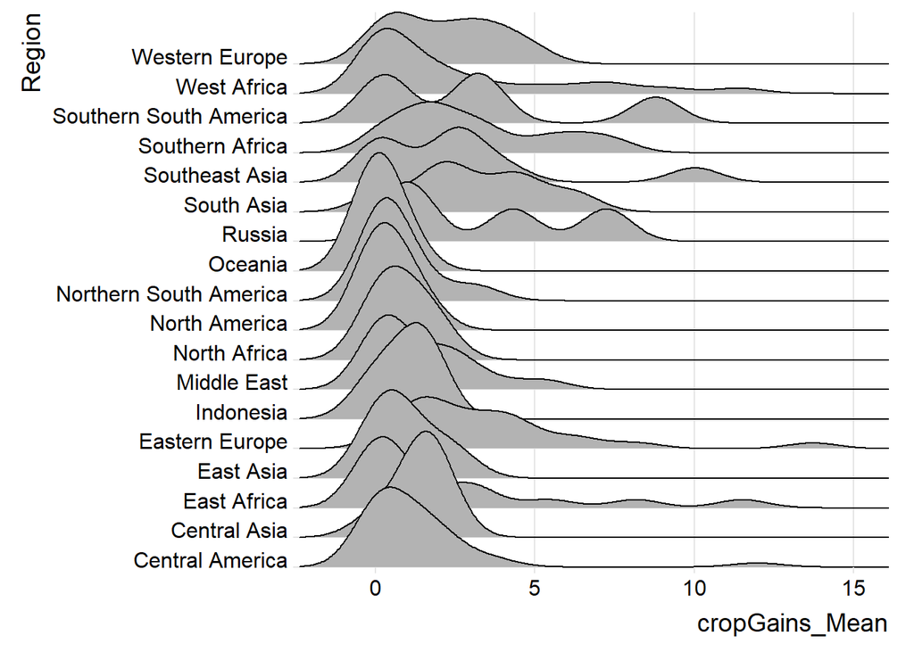

```r
cropGainPlot<-ggplot(summary, aes(x = cropGains_Mean, y = Region)) +
  geom_density_ridges(scale = 4) +
  scale_y_discrete(expand = c(0, 0)) +     # will generally have to set the `expand` option
  scale_x_continuous(expand = c(0, 0)) +   # for both axes to remove unneeded padding
  coord_cartesian(clip = "off") + # to avoid clipping of the very top of the top ridgeline
  theme_ridges()


cropGainPlot
```

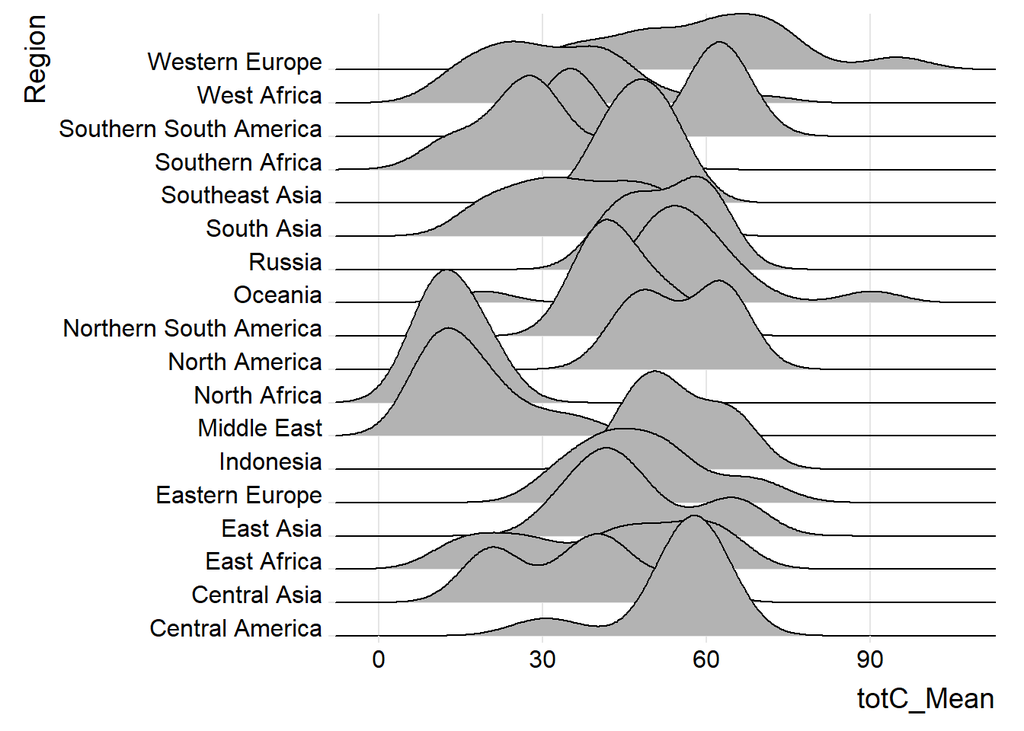

```r
SOCPlot<-ggplot(summary, aes(x = totC_Mean, y = Region)) +
  geom_density_ridges(scale = 4) +
  scale_y_discrete(expand = c(0, 0)) +     # will generally have to set the `expand` option
  scale_x_continuous(expand = c(0, 0)) +   # for both axes to remove unneeded padding
  coord_cartesian(clip = "off") + # to avoid clipping of the very top of the top ridgeline
  theme_ridges()

SOCPlot
```

## Bivariate Chloropleth Maps By Region

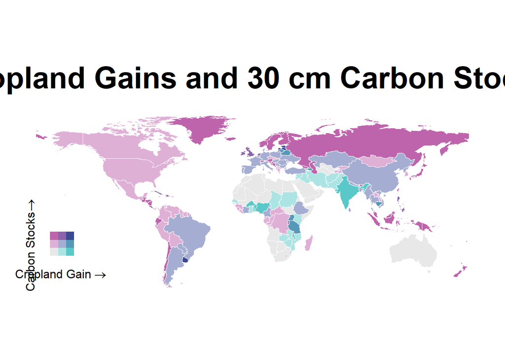

```r
shapes<-na.omit(shapes)

shapes <- bi_class(shapes, x = cropGains_Mean, y = totC_Mean, style = "jenks", dim = 3)

map <- ggplot() +
  geom_sf(data = shapes, mapping = aes(fill = bi_class), color = "white", size = 0.1, show.legend = FALSE) +
  bi_scale_fill(pal = "DkBlue", dim = 3) +
  labs(
    title = "Cropland Gains and 30 cm Carbon Stocks",
  ) +
  bi_theme()

legend <- bi_legend(pal = "DkBlue",
                    dim = 3,
                    xlab = "Cropland Gain",
                    ylab = "Carbon Stocks",
                    size = 12)

finalPlot <- ggdraw() +
  draw_plot(map, 0, 0, 1, 1) +
  draw_plot(legend, 0, 0.2, 0.2, 0.2)


finalPlot
```

## Dyanamic Country Results

```r
newShape<-shapes
newShape$geometry<-NULL

highRisk<-newShape %>%
  filter(bi_class == '3-3'|bi_class == '3-2') %>%
  select(NAME_0, bi_class, Continent, totC_Mean, cropGains_Mean)

highRisk
```

```
##        NAME_0 bi_class     Continent totC_Mean cropGains_Mean
## 1  Azerbaijan      3-2          Asia  42.91636       7.251426
## 2     Belarus      3-2        Europe  35.43983       6.096657
## 3    Barbados      3-3 North America  53.69674      11.969048
## 4     Estonia      3-3        Europe  66.96027       6.431501
## 5    Cambodia      3-2          Asia  41.92271      10.016696
## 6   Lithuania      3-2        Europe  40.46164      13.716304
## 7      Latvia      3-3        Europe  53.71252       8.178349
## 8      Rwanda      3-3        Africa  61.77108       8.167065
## 9    Tanzania      3-2        Africa  33.02401       7.414059
## 10     Uganda      3-2        Africa  51.27988      11.502319
## 11    Uruguay      3-3 South America  59.96348       8.791050
```

# Detailed Analysis

```r
target<-gains>=10


targMask<-classify(
#define the raster you are clipping
target,
#define the reclassification values (id is 0= not in the 10% or more)
cbind(id=c(0, 1),
#these are the raster values, with an id of 0 returning as an NA, otherwise it is 1.
v=c(NA, 1)),
filename='targMask.tif')
```

```r
targetMask<-rast("targMask.tif")
```

```r
highCrop<-mask(
#the first raster is the full raster we are cutting (the soil carbon stocks)
scStock,
#the second raster is the mask we created in the previous step
targetMask,
#If TRUE, areas on mask that are _not_ the maskvalue are masked, since we classified them as NA, this can be set to false
inverse=FALSE,
#The value that cells of x should become if they are not covered by mask, set to NA here.
updatevalue=NA,
#new creation of a .tif file, with the cut values of soil carbon remaining.
filename="highCrop_SOC_Stocks.tif")
```

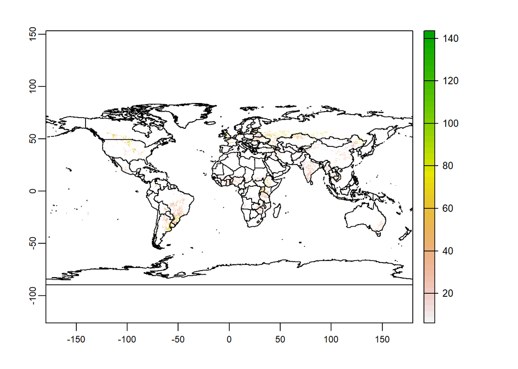

```r
highCropCh<-rast("highCrop_SOC_Stocks.tif")

plot(highCropCh)
plot(w, bg="transparent", add=TRUE)
```

```r
shapes$hCCount<-exact_extract(highCropCh, shapes, 'count')
shapes$hcMean<-exact_extract(highCropCh, shapes, 'mean')
```

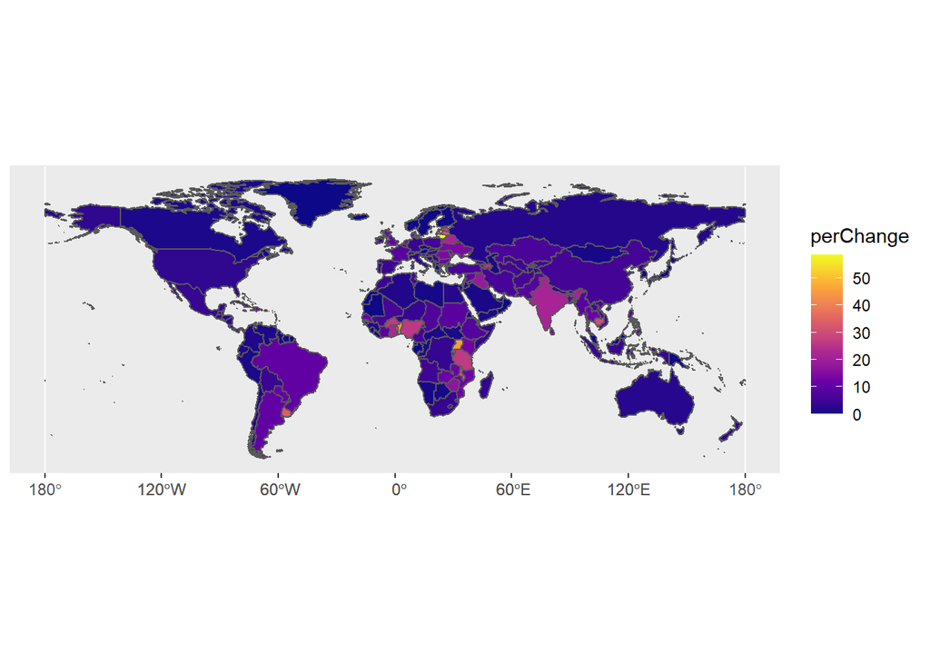

```r
shapes$perChange<-(shapes$hCCount/shapes$TotalCount)*100

ggplot(data = shapes) +
    geom_sf(aes(fill = perChange)) +
    scale_fill_viridis_c(option = "plasma")
```

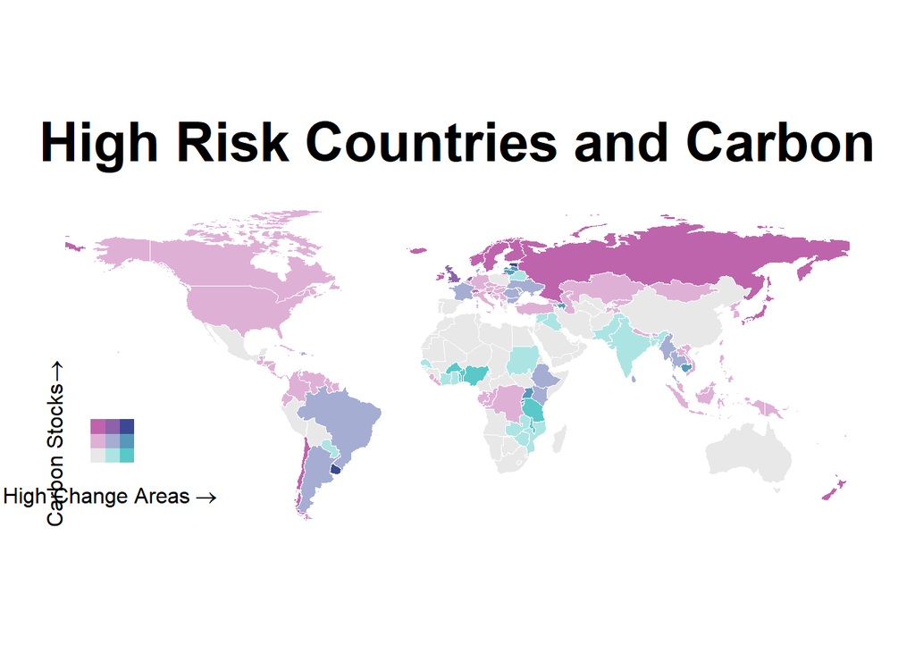

```r
shapes2<-na.omit(shapes)

shapes2 <- bi_class(shapes2, x = perChange, y = hcMean, style = "jenks", dim = 3)

map <- ggplot() +
  geom_sf(data = shapes2, mapping = aes(fill = bi_class), color = "white", size = 0.1, show.legend = FALSE) +
  bi_scale_fill(pal = "DkBlue", dim = 3) +
  labs(
    title = "High Risk Countries and Carbon",
  ) +
  bi_theme()

legend <- bi_legend(pal = "DkBlue",
                    dim = 3,
                    xlab = "High Change Areas",
                    ylab = "Carbon Stocks",
                    size = 12)

finalPlot2 <- ggdraw() +
  draw_plot(map, 0, 0, 1, 1) +
  draw_plot(legend, 0, 0.2, 0.2, 0.2)


finalPlot2
```

```r
newShape1<-shapes2
newShape1$geometry<-NULL

highRisk<-newShape1 %>%
  filter(bi_class == '3-3'|bi_class == '3-2'|bi_class == '2-3'|bi_class == '3-3') %>%
  select(NAME_0, bi_class, Continent, totC_Mean, perChange)

highRisk
```

```
##            NAME_0 bi_class     Continent totC_Mean perChange
## 1      Azerbaijan      3-2          Asia  42.91636  25.11263
## 2        Barbados      3-2 North America  53.69674  58.37006
## 3         Estonia      3-3        Europe  66.96027  27.10306
## 4  United Kingdom      2-3        Europe  72.97118  10.38440
## 5     Isle of Man      2-3        Europe  72.40746  10.89843
## 6        Cambodia      3-2          Asia  41.92271  30.22134
## 7       Lithuania      3-2        Europe  40.46164  57.63790
## 8          Latvia      3-2        Europe  53.71252  32.76434
## 9     Netherlands      2-3        Europe  59.25650  14.37528
## 10         Rwanda      3-2        Africa  61.77108  31.66588
## 11         Uganda      3-2        Africa  51.27988  45.13052
## 12        Uruguay      3-3 South America  59.96348  33.77368
```